# feather

2021-01-07

There are so many lovely packages for colour palettes (see links at the bottom of [this post](http://jenrichmond.rbind.io/post/idhtg-how-to-use-colour-palettes-with-ggplot/) for more).

This new one called `feather`` by [Shandiya Balasubramanium](https://shandiyabalasubramaniam.weebly.com/) is inspired by Australian birds and is delightful.

> Today I built my first R package! Meet feather: a set of colour palettes inspired by the plumage of Australian birds. It's a work in progress and a bit rough around the edges, but I'm pretty proud of it[#RStats](https://twitter.com/hashtag/RStats?src=hash&ref_src=twsrc%5Etfw) [#WildOz](https://twitter.com/hashtag/WildOz?src=hash&ref_src=twsrc%5Etfw) [#DataVisualization](https://twitter.com/hashtag/DataVisualization?src=hash&ref_src=twsrc%5Etfw) https://t.co/9kjavQ4Q50

> — Shandiya Balasubramaniam (@ShandiyaB) [January 7, 2021](https://twitter.com/ShandiyaB/status/1347116050714816513?ref_src=twsrc%5Etfw)

The vignette doesn’t have any pictures of the birds though, so I thought it might be a good opportunity to help [Shandiya](https://twitter.com/ShandiyaB) out and try my first pull request! I am documenting the process here, so I can refer back to it for next time.

# Trying out the feather package

I’ve installed the feather package from github…

```r
devtools::install_github("shandiya/feather")
```

… and loaded the palette names

```r
library(feather)

names(feather_palettes)
```

```
## [1] "pardalote"               "plains_wanderer"
## [3] "bee_eater"               "rose_crowned_fruit_dove"
## [5] "eastern_rosella"
```

You can print each palette by using the `get_pal()` function and the `print_pal()` function. There is the palette for the Eastern Rosella

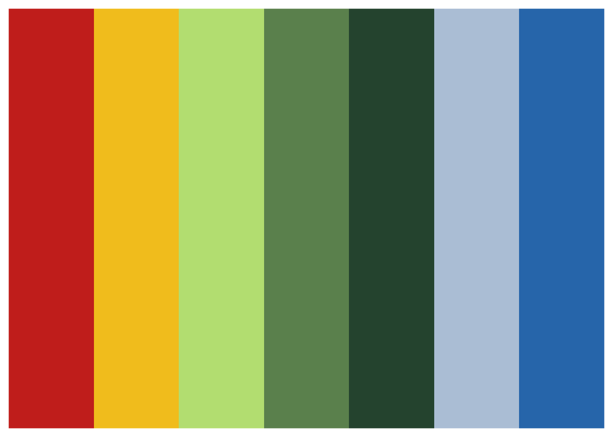

```r
er <- get_pal("eastern_rosella")

print_pal(er)
```

# Adding bird images for each palette

## Eastern Rosella

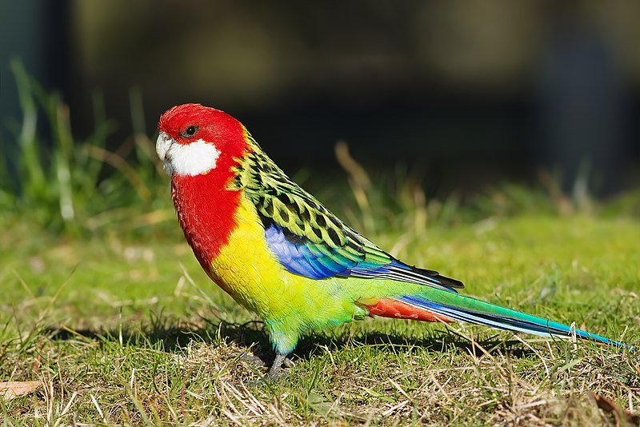

Image credit: [JJ Harrison](https://www.jjharrison.com.au/). This file is licensed under the [Creative Commons](https://en.wikipedia.org/wiki/Creative_Commons) [Attribution-Share Alike 3.0 Unported license](https://creativecommons.org/licenses/by-sa/3.0/deed.en). Image source: [Wikimedia Commons](https://commons.wikimedia.org/wiki/File:Platycercus_eximius_diemenensis_male.jpg).

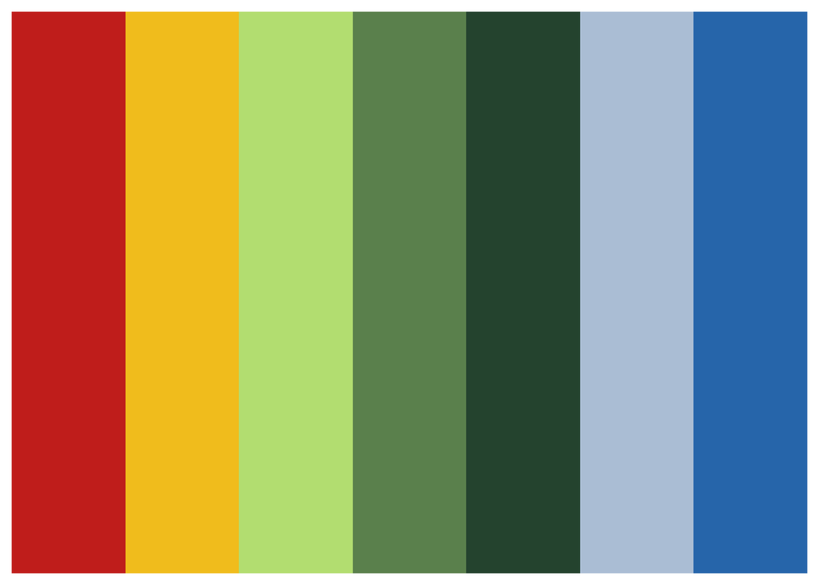

## Plains wanderer

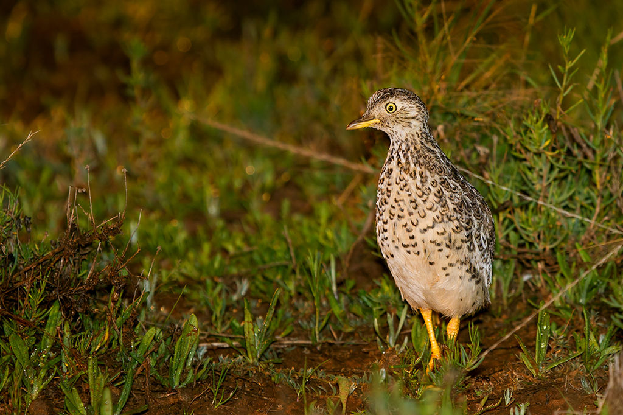

Image credit: [Patrick_K59](https://www.flickr.com/photos/patrick_k59/14368940377/). This file is licensed under the CC BY 2.0, https://commons.wikimedia.org/w/index.php?curid=34831381. Image source: [Wikimedia Commons](https://commons.wikimedia.org/wiki/File:Pedionomus_torquatus,_NSW_1.jpg).

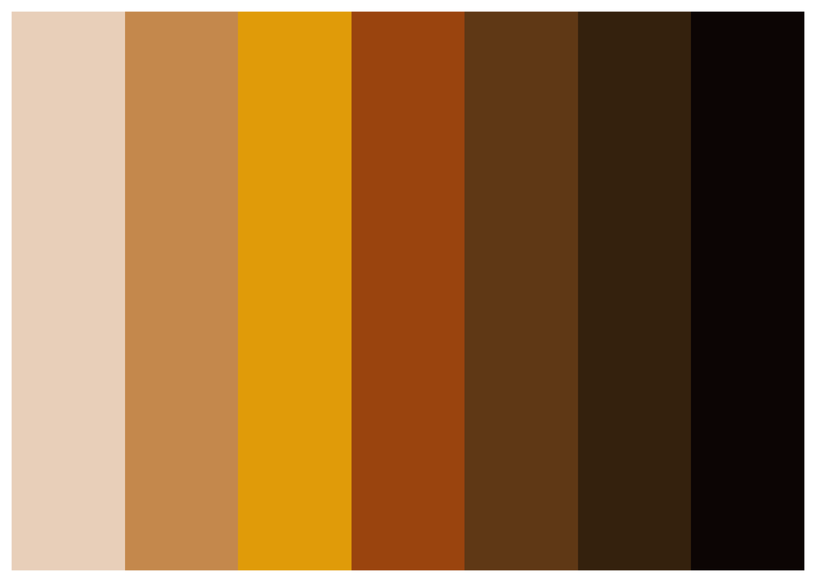

## Pardalote

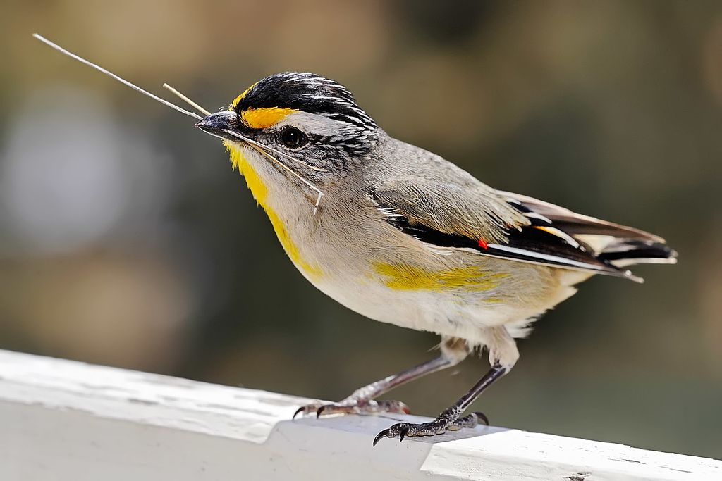

Image credit: [Fir0002 - Own work, GFDL 1.2](https://commons.wikimedia.org/w/index.php?curid=1535942). This file is licensed under the [Creative Commons](https://en.wikipedia.org/wiki/Creative_Commons), [Attribution NonCommercial Unported 3.0](https://creativecommons.org/licenses/by-nc/3.0/). Image source: [Wikimedia Commons](https://commons.wikimedia.org/wiki/File:Pardalotus_with_nesting_material.jpg).

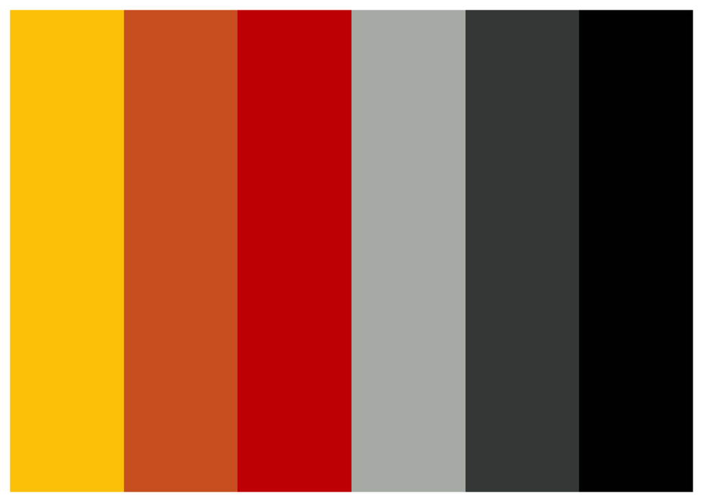

## Rose crowned fruit dove

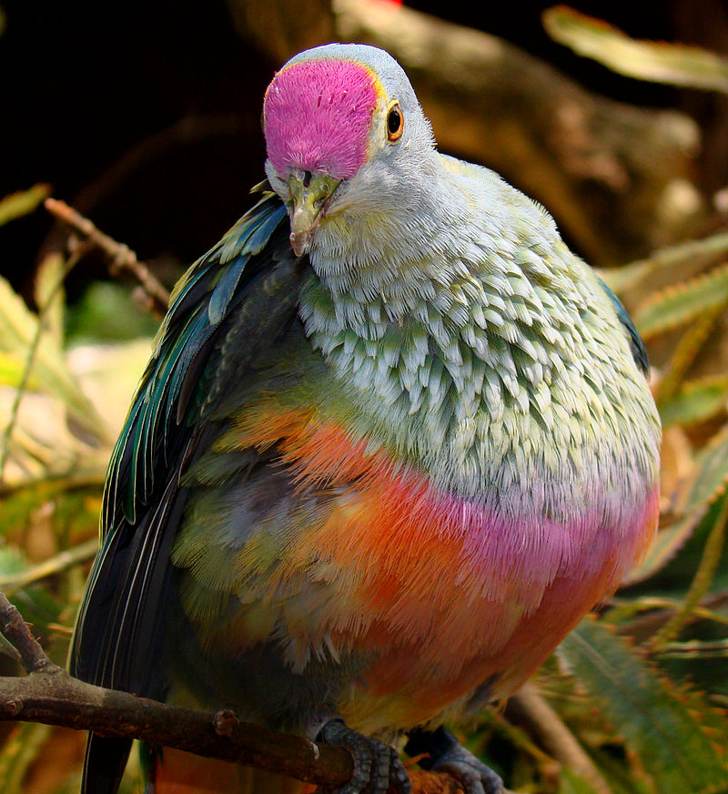

Image credit: [Bjørn Christian Tørrissen](http://bjornfree.com/galleries.html), CC BY-SA 3.0, https://commons.wikimedia.org/w/index.php?curid=6874281

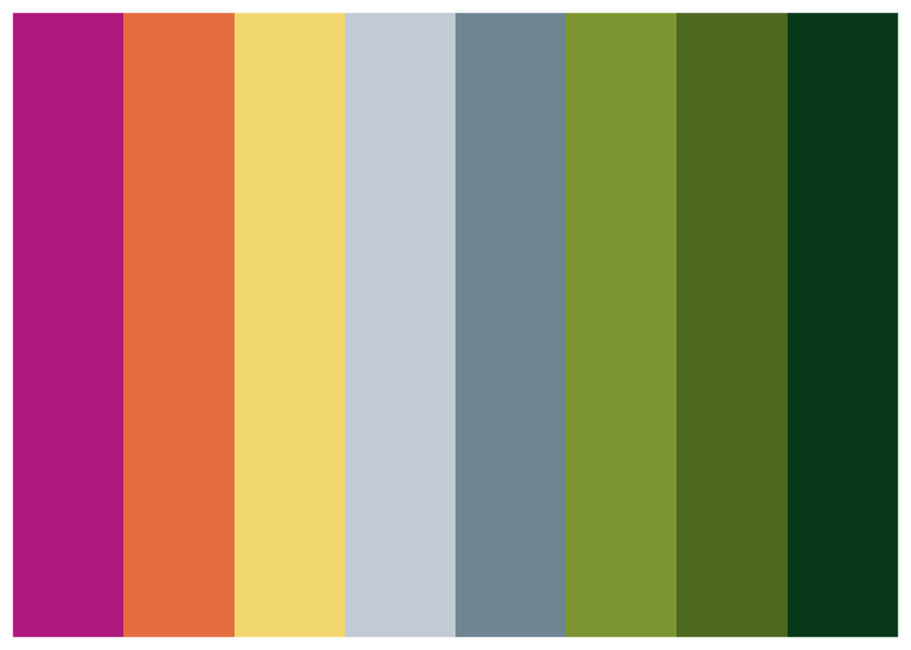

## Bee eater

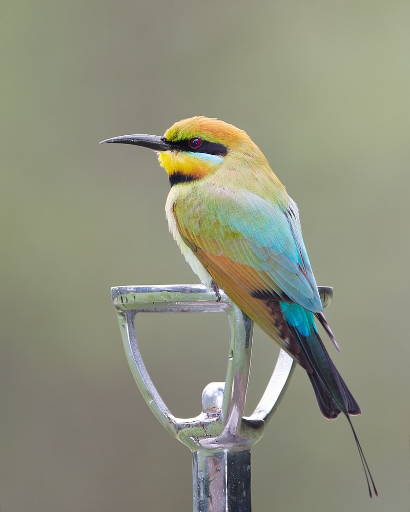

[JJ Harrison](https://www.jjharrison.com.au/). This file is licensed under the [Creative Commons](https://en.wikipedia.org/wiki/Creative_Commons) [Attribution-Share Alike 3.0 Unported license](https://creativecommons.org/licenses/by-sa/3.0/deed.en). Image source: [Wikimedia Commons](https://commons.wikimedia.org/wiki/File:Merops_ornatus_-_Centenary_Lakes.jpg).

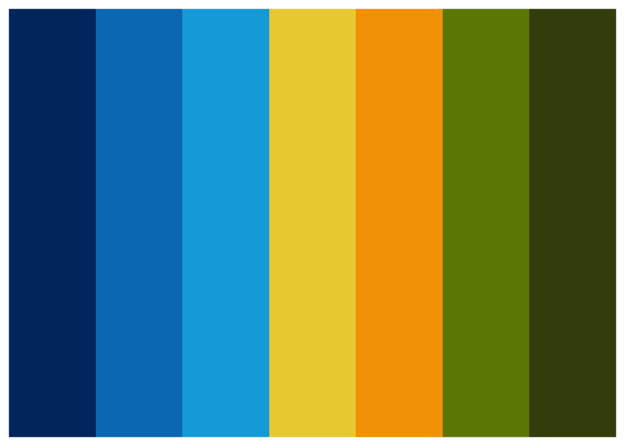

# Contributing to a package with a pull request

When making a pull request you are asking the person who wrote the package (or who owns the repo) to pull the changes you have made into the original repo.

https://docs.github.com/en/free-pro-team@latest/github/collaborating-with-issues-and-pull-requests/creating-a-pull-request-from-a-fork

### Step 1: fork the repo

Forking is the process of creating a copy of the repo into your github account.

### Step 2: clone the repo

Use the green button to clone the forked copy on to your machine. You can copy the url and use New project- From Version control. Or in the terminal use

1. `pwd` to print your working directory and then
2. `cd` to navigate to the folder where you want to clone
3. `git clone "paste URL"` to clone the repo into that location

```
pwd

cd Users/jenny/Desktop/git

git clone "paste URL here"
```

### Step 3: make changes to your local copy

### Step 4: push your changes to your forked copy

https://docs.github.com/en/free-pro-team@latest/github/collaborating-with-issues-and-pull-requests/creating-a-pull-request-from-a-fork